# Predicting Exercising Class from HAR Datasets

Harvinder

Sunday, Oct 23, 2014

## Synopsis

The objective is to predict the exercising manner from the HAR datasets. The training and test dataset is available from the following links.

https://d396qusza40orc.cloudfront.net/predmachlearn/pml-training.csv

https://d396qusza40orc.cloudfront.net/predmachlearn/pml-testing.csv

The data is downloaded locally into training.csv and testing.csv files before further processing is done on it.

```r
data <- read.csv("training.csv")
testing <- read.csv("testing.csv")
dim(data); dim(testing)
```

```
## [1] 19622   160
```

```
## [1]  20 160
```

### Approach

In the absence any domain expertise in this area, following steps were executed:

- Clean the data, remove features for which data is not available or hardly available.
- Find the correlation between the features.
- Partition the data into training and test set.
- Reduce the number of dimension or features.
- Apply model which works for classification problems.

### Data Cleaning

```r
data.nonNACols <- unlist(lapply(data, function(x) !any(is.na(x))), use.names=FALSE)
data.nonNA <- data[, data.nonNACols]
testing.nonNACols <- unlist(lapply(testing, function(x) !any(is.na(x))), use.names=FALSE)
testing.nonNA <-  testing[, testing.nonNACols]
dim(data.nonNA);dim(testing.nonNA)
```

```
## [1] 19622    93
```

```
## [1] 20 60
```

It shows that number of cols are not same in both the data set. Let us make it equal by considering only those columns which are available in both the data set.

```r
data.nonNA.both <- ( data.nonNACols &  testing.nonNACols)
data.nonNA <- data[, data.nonNA.both]
testing.nonNA <-  testing[, data.nonNA.both]
dim(data.nonNA);dim(testing.nonNA)
```

```
## [1] 19622    60
```

```
## [1] 20 60
```

### Dimension Reduction

- Find the correlation between features by keeping a high threshold of .8. For this first step is to convert all the features into numeric

```r
classeVar <- data.nonNA$classe
data.nonNA <- data.frame(lapply(data.nonNA[,-60] , function(x) as.numeric(x)))
data.nonNA$classe <- classeVar
```

- Find the correlation and display the number of highly correlated features.

```r
c <- abs(cor(data.nonNA[,-60]))
diag(c) <- 0
nrow(which(c > .8, arr.ind=T))
```

```
## [1] 42
```

#### Data Partitioning, Model Building and Cross Validation

- Partition the training data into training and testing for cross validation. Use caret package for these tasks.

```r
library(caret)
inTrain <- createDataPartition(data.nonNA$classe, p=.7, list=FALSE)
data.training <- data.nonNA[inTrain, ]
data.testing <- data.nonNA[-inTrain,]
dim(data.training); dim(data.testing )
```

```
## [1] 13737    60
```

```
## [1] 5885   60
```

- Apply PCA on the training data set to reduce the dimensions

```r
set.seed(145778)
preProcess <- preProcess(data.training[,-60], method="pca", thresh=.99)
data.pca <- predict( preProcess, data.training[,-60])
dim(data.pca )
```

```
## [1] 13737    39
```

- After applying PCA, knn (k nearest neighbour) method is used for classification as knn is good fit for both classification and regression problems.

Please note: Apply pca on testing data as well before validating using preProcess on training data.

```r
model <- train(data.training$classe ~., method="knn", data=data.pca)
data.pca.test <- predict( preProcess, data.testing[,-60])
pred <- predict(model, data.pca.test)
confusionMatrix(pred, data.testing$classe )
```

```
## Confusion Matrix and Statistics
##
##           Reference
## Prediction    A    B    C    D    E
##          A 1649   26    7    1    1
##          B   18 1069   17    3    5
##          C    3   36  980   40    7
##          D    3    5   22  916   14
##          E    1    3    0    4 1055
##
## Overall Statistics
##
##                Accuracy : 0.963
##                  95% CI : (0.958, 0.968)
##     No Information Rate : 0.284
##     P-Value [Acc > NIR] : < 2e-16
##
##                   Kappa : 0.954
##  Mcnemar's Test P-Value : 0.000978
##
## Statistics by Class:
##
##                      Class: A Class: B Class: C Class: D Class: E
## Sensitivity             0.985    0.939    0.955    0.950    0.975
## Specificity             0.992    0.991    0.982    0.991    0.998
## Pos Pred Value          0.979    0.961    0.919    0.954    0.992
## Neg Pred Value          0.994    0.985    0.990    0.990    0.994
## Prevalence              0.284    0.194    0.174    0.164    0.184
## Detection Rate          0.280    0.182    0.167    0.156    0.179
## Detection Prevalence    0.286    0.189    0.181    0.163    0.181
## Balanced Accuracy       0.988    0.965    0.969    0.971    0.987
```

### Inference

It was found that accurace is high 96% and p-value is quite low. This model could be a good fit. The plot shows that 5 nearest neighbour gives the best accuracy.

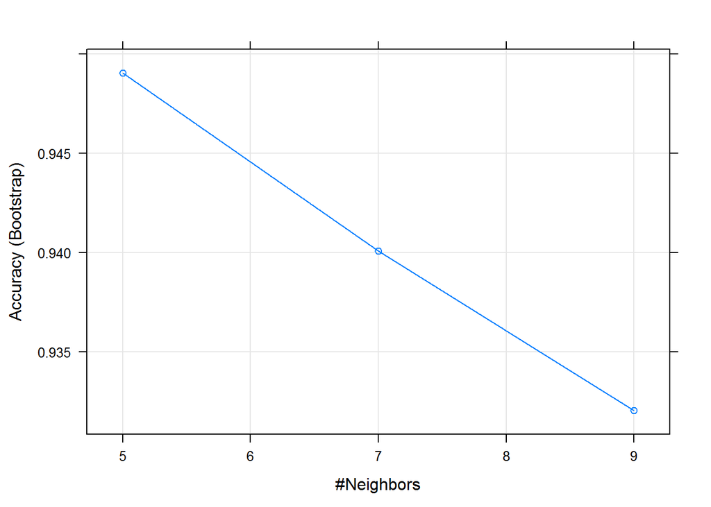

```r
plot(model)
```

The out of sample error is given below, which is quite low

```r
1- confusionMatrix(pred, data.testing$classe )$overall[[1]]
```

```
## [1] 0.0367
```

### Execute Test

- Run this model on the provided test data only once.
- Prepare the test data before applying it on the model. The data is already cleaned before in the variable testing.nonNA

```r
testing.nonNA <- data.frame(lapply(testing.nonNA[,-60] , function(x) as.numeric(x)))
testing.pca.test <- predict( preProcess, testing.nonNA[,-60])
pred <- predict(model, testing.pca.test)
as.character(pred)
```

```
##  [1] "B" "A" "A" "A" "A" "C" "D" "B" "A" "A" "B" "A" "B" "A" "E" "A" "A"
## [18] "B" "B" "B"
```

### Conclusion

It was found by running the test cases on the coursera that 16 outof 20 are correct, which is fairly good prediction.

### Appendix

This section has the complete code as function

```r
myPredictionModel <- function()
{

    data <- read.csv("https://d396qusza40orc.cloudfront.net/predmachlearn/pml-training.csv")
    testing <- read.csv("https://d396qusza40orc.cloudfront.net/predmachlearn/pml-testing.csv")
    data.nonNACols <- unlist(lapply(data, function(x) !any(is.na(x))), use.names=FALSE)
    data.nonNA <- data[, data.nonNACols]

    testing.nonNACols <- unlist(lapply(testing, function(x) !any(is.na(x))), use.names=FALSE)
    testing.nonNA <-  testing[, testing.nonNACols]

    data.nonNA.both <- ( data.nonNACols &  testing.nonNACols)
    data.nonNA <- data[, data.nonNA.both]
    testing.nonNA <-  testing[, data.nonNA.both]

    classeVar <- data.nonNA$classe
    data.nonNA <- data.frame(lapply(data.nonNA[,-60] , function(x) as.numeric(x)))
    data.nonNA$classe <- classeVar

    inTrain <- createDataPartition(data.nonNA$classe, p=.7, list=FALSE)
    data.training <- data.nonNA[inTrain, ]
    data.testing <- data.nonNA[-inTrain,]

    preProcess <- preProcess(data.training[,-60], method="pca", thresh=.99)
    data.pca <- predict( preProcess, data.training[,-60])

    model <- train(data.training$classe ~., method="knn", data=data.pca)
    data.pca.test <- predict( preProcess, data.testing[,-60])
    pred <- predict(model, data.pca.test)
    con <-  confusionMatrix(pred, data.testing$classe )


    testing.nonNA <- data.frame(lapply(testing.nonNA[,-60] , function(x) as.numeric(x)))
    testing.pca.test <- predict( preProcess, testing.nonNA[,-60])
    pred <- predict(model, testing.pca.test)
    as.character(pred)

}
```